# Hotel Booking Cancellation Prediction Project

```python
#importing neccessary modules
import pandas as pd
import numpy as np
import matplotlib.pyplot as plt
import seaborn as sns
import warnings
warnings.filterwarnings("ignore")
```

```python
#importing dataset
df= pd.read_csv(r"C:\Users\IIJet\Downloads\booking.csv")
```

```python
df
```

|  | Booking_ID | number of adults | number of children | number of weekend nights | number of week nights | type of meal | car parking space | room type | lead time | market segment type | repeated | P-C | P-not-C | average price | special requests | date of reservation | booking status |
| --- | --- | --- | --- | --- | --- | --- | --- | --- | --- | --- | --- | --- | --- | --- | --- | --- | --- |
| 0 | INN00001 | 1 | 1 | 2 | 5 | Meal Plan 1 | 0 | Room_Type 1 | 224 | Offline | 0 | 0 | 0 | 88.00 | 0 | 10/2/2015 | Not_Canceled |
| 1 | INN00002 | 1 | 0 | 1 | 3 | Not Selected | 0 | Room_Type 1 | 5 | Online | 0 | 0 | 0 | 106.68 | 1 | 11/6/2018 | Not_Canceled |
| 2 | INN00003 | 2 | 1 | 1 | 3 | Meal Plan 1 | 0 | Room_Type 1 | 1 | Online | 0 | 0 | 0 | 50.00 | 0 | 2/28/2018 | Canceled |
| 3 | INN00004 | 1 | 0 | 0 | 2 | Meal Plan 1 | 0 | Room_Type 1 | 211 | Online | 0 | 0 | 0 | 100.00 | 1 | 5/20/2017 | Canceled |
| 4 | INN00005 | 1 | 0 | 1 | 2 | Not Selected | 0 | Room_Type 1 | 48 | Online | 0 | 0 | 0 | 77.00 | 0 | 4/11/2018 | Canceled |
| ... | ... | ... | ... | ... | ... | ... | ... | ... | ... | ... | ... | ... | ... | ... | ... | ... | ... |
| 36280 | INN36282 | 2 | 0 | 0 | 2 | Meal Plan 2 | 0 | Room_Type 1 | 346 | Online | 0 | 0 | 0 | 115.00 | 1 | 9/13/2018 | Canceled |
| 36281 | INN36283 | 2 | 0 | 1 | 3 | Meal Plan 1 | 0 | Room_Type 1 | 34 | Online | 0 | 0 | 0 | 107.55 | 1 | 10/15/2017 | Not_Canceled |
| 36282 | INN36284 | 2 | 0 | 1 | 3 | Meal Plan 1 | 0 | Room_Type 4 | 83 | Online | 0 | 0 | 0 | 105.61 | 1 | 12/26/2018 | Not_Canceled |
| 36283 | INN36285 | 3 | 0 | 0 | 4 | Meal Plan 1 | 0 | Room_Type 1 | 121 | Offline | 0 | 0 | 0 | 96.90 | 1 | 7/6/2018 | Not_Canceled |
| 36284 | INN36286 | 2 | 0 | 0 | 5 | Meal Plan 1 | 0 | Room_Type 4 | 44 | Online | 0 | 0 | 0 | 133.44 | 3 | 10/18/2018 | Not_Canceled |

36285 rows × 17 columns

```python
#checking null data
df.isnull().sum()
```

```
Booking_ID                  0
number of adults            0
number of children          0
number of weekend nights    0
number of week nights       0
type of meal                0
car parking space           0
room type                   0
lead time                   0
market segment type         0
repeated                    0
P-C                         0
P-not-C                     0
average price               0
special requests            0
date of reservation         0
booking status              0
dtype: int64
```

```python
# using replace function to perform label encoding
df["booking status"]= df["booking status"].replace("Canceled",1)
df["booking status"]= df["booking status"].replace("Not_Canceled",0)
```

```python
df
```

|  | Booking_ID | number of adults | number of children | number of weekend nights | number of week nights | type of meal | car parking space | room type | lead time | market segment type | repeated | P-C | P-not-C | average price | special requests | date of reservation | booking status |
| --- | --- | --- | --- | --- | --- | --- | --- | --- | --- | --- | --- | --- | --- | --- | --- | --- | --- |
| 0 | INN00001 | 1 | 1 | 2 | 5 | Meal Plan 1 | 0 | Room_Type 1 | 224 | Offline | 0 | 0 | 0 | 88.00 | 0 | 10/2/2015 | 0 |
| 1 | INN00002 | 1 | 0 | 1 | 3 | Not Selected | 0 | Room_Type 1 | 5 | Online | 0 | 0 | 0 | 106.68 | 1 | 11/6/2018 | 0 |
| 2 | INN00003 | 2 | 1 | 1 | 3 | Meal Plan 1 | 0 | Room_Type 1 | 1 | Online | 0 | 0 | 0 | 50.00 | 0 | 2/28/2018 | 1 |
| 3 | INN00004 | 1 | 0 | 0 | 2 | Meal Plan 1 | 0 | Room_Type 1 | 211 | Online | 0 | 0 | 0 | 100.00 | 1 | 5/20/2017 | 1 |
| 4 | INN00005 | 1 | 0 | 1 | 2 | Not Selected | 0 | Room_Type 1 | 48 | Online | 0 | 0 | 0 | 77.00 | 0 | 4/11/2018 | 1 |
| ... | ... | ... | ... | ... | ... | ... | ... | ... | ... | ... | ... | ... | ... | ... | ... | ... | ... |
| 36280 | INN36282 | 2 | 0 | 0 | 2 | Meal Plan 2 | 0 | Room_Type 1 | 346 | Online | 0 | 0 | 0 | 115.00 | 1 | 9/13/2018 | 1 |
| 36281 | INN36283 | 2 | 0 | 1 | 3 | Meal Plan 1 | 0 | Room_Type 1 | 34 | Online | 0 | 0 | 0 | 107.55 | 1 | 10/15/2017 | 0 |
| 36282 | INN36284 | 2 | 0 | 1 | 3 | Meal Plan 1 | 0 | Room_Type 4 | 83 | Online | 0 | 0 | 0 | 105.61 | 1 | 12/26/2018 | 0 |
| 36283 | INN36285 | 3 | 0 | 0 | 4 | Meal Plan 1 | 0 | Room_Type 1 | 121 | Offline | 0 | 0 | 0 | 96.90 | 1 | 7/6/2018 | 0 |
| 36284 | INN36286 | 2 | 0 | 0 | 5 | Meal Plan 1 | 0 | Room_Type 4 | 44 | Online | 0 | 0 | 0 | 133.44 | 3 | 10/18/2018 | 0 |

36285 rows × 17 columns

```python
# Checking summary of data
df.info()
```

```
<class 'pandas.core.frame.DataFrame'>
RangeIndex: 36285 entries, 0 to 36284
Data columns (total 17 columns):
 #   Column                    Non-Null Count  Dtype
---  ------                    --------------  -----
 0   Booking_ID                36285 non-null  object
 1   number of adults          36285 non-null  int64
 2   number of children        36285 non-null  int64
 3   number of weekend nights  36285 non-null  int64
 4   number of week nights     36285 non-null  int64
 5   type of meal              36285 non-null  object
 6   car parking space         36285 non-null  int64
 7   room type                 36285 non-null  object
 8   lead time                 36285 non-null  int64
 9   market segment type       36285 non-null  object
 10  repeated                  36285 non-null  int64
 11  P-C                       36285 non-null  int64
 12  P-not-C                   36285 non-null  int64
 13  average price             36285 non-null  float64
 14  special requests          36285 non-null  int64
 15  date of reservation       36285 non-null  object
 16  booking status            36285 non-null  int64
dtypes: float64(1), int64(11), object(5)
memory usage: 4.7+ MB
```

```python
# Dropping column booking ID from dataframe
df.drop(columns=['Booking_ID'], inplace=True)
```

```python
# Checking specific date 2018-2-29 because based on research 2018 is not a leap year until 2020
df[df["date of reservation"]=="2018-2-29"]
```

|  | number of adults | number of children | number of weekend nights | number of week nights | type of meal | car parking space | room type | lead time | market segment type | repeated | P-C | P-not-C | average price | special requests | date of reservation | booking status |
| --- | --- | --- | --- | --- | --- | --- | --- | --- | --- | --- | --- | --- | --- | --- | --- | --- |
| 2626 | 2 | 0 | 1 | 5 | Meal Plan 1 | 0 | Room_Type 1 | 104 | Online | 1 | 1 | 0 | 61.43 | 0 | 2018-2-29 | 1 |
| 3677 | 1 | 0 | 1 | 3 | Meal Plan 1 | 0 | Room_Type 1 | 21 | Online | 0 | 0 | 0 | 102.05 | 0 | 2018-2-29 | 1 |
| 5600 | 2 | 0 | 1 | 3 | Meal Plan 1 | 0 | Room_Type 1 | 24 | Offline | 0 | 0 | 0 | 45.50 | 0 | 2018-2-29 | 0 |
| 6343 | 1 | 0 | 1 | 1 | Meal Plan 1 | 0 | Room_Type 1 | 117 | Offline | 0 | 0 | 0 | 76.00 | 0 | 2018-2-29 | 0 |
| 7648 | 2 | 1 | 1 | 5 | Meal Plan 1 | 0 | Room_Type 1 | 35 | Online | 0 | 0 | 0 | 98.10 | 1 | 2018-2-29 | 1 |
| 8000 | 2 | 2 | 1 | 3 | Meal Plan 1 | 0 | Room_Type 6 | 3 | Online | 0 | 0 | 0 | 183.00 | 1 | 2018-2-29 | 0 |
| 8989 | 1 | 0 | 1 | 2 | Meal Plan 1 | 0 | Room_Type 1 | 117 | Offline | 0 | 0 | 0 | 76.00 | 0 | 2018-2-29 | 0 |
| 9153 | 2 | 2 | 1 | 3 | Meal Plan 1 | 0 | Room_Type 6 | 3 | Online | 0 | 0 | 0 | 189.75 | 0 | 2018-2-29 | 0 |
| 9245 | 2 | 0 | 1 | 3 | Meal Plan 1 | 0 | Room_Type 4 | 15 | Online | 0 | 0 | 0 | 85.55 | 1 | 2018-2-29 | 0 |
| 9664 | 1 | 0 | 1 | 0 | Meal Plan 1 | 0 | Room_Type 4 | 21 | Online | 0 | 0 | 0 | 117.00 | 0 | 2018-2-29 | 0 |
| 9934 | 1 | 0 | 1 | 2 | Meal Plan 1 | 0 | Room_Type 1 | 45 | Online | 0 | 0 | 0 | 76.30 | 0 | 2018-2-29 | 0 |
| 10593 | 2 | 0 | 1 | 3 | Meal Plan 1 | 1 | Room_Type 4 | 47 | Online | 0 | 0 | 0 | 99.40 | 1 | 2018-2-29 | 0 |
| 10652 | 2 | 0 | 1 | 2 | Meal Plan 1 | 0 | Room_Type 1 | 117 | Offline | 0 | 0 | 0 | 86.33 | 0 | 2018-2-29 | 0 |
| 10747 | 2 | 0 | 1 | 3 | Meal Plan 1 | 0 | Room_Type 1 | 88 | Online | 0 | 0 | 0 | 56.94 | 0 | 2018-2-29 | 1 |
| 11881 | 1 | 0 | 3 | 7 | Meal Plan 1 | 0 | Room_Type 1 | 58 | Online | 0 | 0 | 0 | 66.45 | 1 | 2018-2-29 | 0 |
| 13958 | 1 | 0 | 1 | 1 | Meal Plan 1 | 0 | Room_Type 1 | 0 | Complementary | 0 | 0 | 0 | 3.00 | 0 | 2018-2-29 | 0 |
| 14304 | 2 | 0 | 1 | 3 | Meal Plan 2 | 0 | Room_Type 1 | 13 | Online | 0 | 0 | 0 | 114.55 | 0 | 2018-2-29 | 0 |
| 15363 | 1 | 0 | 1 | 2 | Meal Plan 1 | 0 | Room_Type 1 | 61 | Online | 0 | 0 | 0 | 78.90 | 1 | 2018-2-29 | 1 |
| 15438 | 1 | 0 | 1 | 2 | Meal Plan 1 | 0 | Room_Type 1 | 1 | Offline | 0 | 0 | 0 | 76.00 | 0 | 2018-2-29 | 0 |
| 17202 | 2 | 0 | 1 | 3 | Meal Plan 2 | 0 | Room_Type 1 | 13 | Online | 0 | 0 | 0 | 107.80 | 0 | 2018-2-29 | 0 |
| 18380 | 1 | 0 | 1 | 1 | Meal Plan 1 | 0 | Room_Type 1 | 117 | Offline | 0 | 0 | 0 | 76.00 | 0 | 2018-2-29 | 0 |
| 18534 | 1 | 0 | 1 | 2 | Meal Plan 1 | 0 | Room_Type 5 | 3 | Corporate | 0 | 0 | 0 | 107.00 | 0 | 2018-2-29 | 0 |
| 18680 | 1 | 0 | 1 | 4 | Meal Plan 1 | 1 | Room_Type 1 | 4 | Corporate | 1 | 0 | 11 | 68.00 | 1 | 2018-2-29 | 0 |
| 19013 | 1 | 0 | 1 | 1 | Meal Plan 1 | 1 | Room_Type 1 | 7 | Corporate | 0 | 0 | 0 | 68.00 | 0 | 2018-2-29 | 0 |
| 20419 | 2 | 0 | 1 | 1 | Meal Plan 1 | 0 | Room_Type 4 | 33 | Online | 0 | 0 | 0 | 106.40 | 0 | 2018-2-29 | 0 |
| 21674 | 1 | 0 | 1 | 1 | Meal Plan 1 | 0 | Room_Type 1 | 117 | Offline | 0 | 0 | 0 | 75.00 | 0 | 2018-2-29 | 0 |
| 21688 | 2 | 0 | 1 | 2 | Meal Plan 1 | 0 | Room_Type 4 | 57 | Online | 0 | 0 | 0 | 95.30 | 1 | 2018-2-29 | 0 |
| 26108 | 2 | 0 | 1 | 2 | Meal Plan 1 | 0 | Room_Type 1 | 39 | Online | 0 | 0 | 0 | 60.10 | 0 | 2018-2-29 | 0 |
| 27559 | 1 | 0 | 1 | 0 | Meal Plan 1 | 0 | Room_Type 1 | 0 | Corporate | 1 | 0 | 10 | 65.00 | 1 | 2018-2-29 | 0 |
| 27928 | 2 | 0 | 1 | 5 | Meal Plan 1 | 0 | Room_Type 4 | 115 | Online | 0 | 0 | 0 | 102.33 | 1 | 2018-2-29 | 0 |
| 30552 | 2 | 1 | 1 | 3 | Meal Plan 1 | 0 | Room_Type 4 | 13 | Offline | 0 | 0 | 0 | 86.80 | 0 | 2018-2-29 | 1 |
| 30616 | 1 | 0 | 1 | 0 | Meal Plan 1 | 0 | Room_Type 5 | 21 | Offline | 0 | 0 | 0 | 142.00 | 0 | 2018-2-29 | 0 |
| 30632 | 3 | 0 | 1 | 2 | Meal Plan 2 | 0 | Room_Type 4 | 7 | Online | 0 | 0 | 0 | 193.00 | 2 | 2018-2-29 | 0 |
| 30839 | 1 | 0 | 1 | 2 | Meal Plan 1 | 0 | Room_Type 1 | 117 | Offline | 0 | 0 | 0 | 76.00 | 0 | 2018-2-29 | 0 |
| 32041 | 2 | 0 | 1 | 0 | Not Selected | 0 | Room_Type 1 | 50 | Online | 0 | 0 | 0 | 76.50 | 0 | 2018-2-29 | 1 |
| 34638 | 1 | 0 | 1 | 2 | Meal Plan 1 | 0 | Room_Type 1 | 3 | Corporate | 1 | 0 | 1 | 66.00 | 0 | 2018-2-29 | 0 |
| 35481 | 1 | 0 | 1 | 1 | Meal Plan 1 | 0 | Room_Type 1 | 7 | Corporate | 0 | 0 | 0 | 66.00 | 0 | 2018-2-29 | 0 |

```python
# Since now that there is false date in the data, it is best to get review of date of reservation column by checking through years.
# This will give good idea of what to expect from date/time format and to see if theres any reason to include in features

df= df[df['date of reservation'] != '2018-2-29']

df['date of reservation'] = pd.to_datetime(df['date of reservation'])

df.groupby([df['date of reservation'].dt.year,df['date of reservation'].dt.month])['date of reservation'].count()
```

```
date of reservation  date of reservation
2015                 10                        1
2016                 9                         1
2017                 5                         1
                     7                       363
                     8                      1014
                     9                      1649
                     10                     1914
                     11                      647
                     12                      928
2018                 1                      1014
                     2                      1668
                     3                      2358
                     4                      2737
                     5                      2598
                     6                      3203
                     7                      2558
                     8                      2799
                     9                      2962
                     10                     3405
                     11                     2334
                     12                     2094
Name: date of reservation, dtype: int64
```

```python
# since date of reservation has little role to play in terms of influencing booking cancellation
# also to understand the above grouping of y m d format, we can see 2015 and 2016 with little booking
# while 2017-2018 has had more booking throughout the year including false date in which 2018 is not a leap year
# in terms of relevancy, date of reservation will be removed for the purpose of sensitive data when needed for predictive modeling

df.drop(columns=['date of reservation'], inplace=True)
df
```

|  | number of adults | number of children | number of weekend nights | number of week nights | type of meal | car parking space | room type | lead time | market segment type | repeated | P-C | P-not-C | average price | special requests | booking status |
| --- | --- | --- | --- | --- | --- | --- | --- | --- | --- | --- | --- | --- | --- | --- | --- |
| 0 | 1 | 1 | 2 | 5 | Meal Plan 1 | 0 | Room_Type 1 | 224 | Offline | 0 | 0 | 0 | 88.00 | 0 | 0 |
| 1 | 1 | 0 | 1 | 3 | Not Selected | 0 | Room_Type 1 | 5 | Online | 0 | 0 | 0 | 106.68 | 1 | 0 |
| 2 | 2 | 1 | 1 | 3 | Meal Plan 1 | 0 | Room_Type 1 | 1 | Online | 0 | 0 | 0 | 50.00 | 0 | 1 |
| 3 | 1 | 0 | 0 | 2 | Meal Plan 1 | 0 | Room_Type 1 | 211 | Online | 0 | 0 | 0 | 100.00 | 1 | 1 |
| 4 | 1 | 0 | 1 | 2 | Not Selected | 0 | Room_Type 1 | 48 | Online | 0 | 0 | 0 | 77.00 | 0 | 1 |
| ... | ... | ... | ... | ... | ... | ... | ... | ... | ... | ... | ... | ... | ... | ... | ... |
| 36280 | 2 | 0 | 0 | 2 | Meal Plan 2 | 0 | Room_Type 1 | 346 | Online | 0 | 0 | 0 | 115.00 | 1 | 1 |
| 36281 | 2 | 0 | 1 | 3 | Meal Plan 1 | 0 | Room_Type 1 | 34 | Online | 0 | 0 | 0 | 107.55 | 1 | 0 |
| 36282 | 2 | 0 | 1 | 3 | Meal Plan 1 | 0 | Room_Type 4 | 83 | Online | 0 | 0 | 0 | 105.61 | 1 | 0 |
| 36283 | 3 | 0 | 0 | 4 | Meal Plan 1 | 0 | Room_Type 1 | 121 | Offline | 0 | 0 | 0 | 96.90 | 1 | 0 |
| 36284 | 2 | 0 | 0 | 5 | Meal Plan 1 | 0 | Room_Type 4 | 44 | Online | 0 | 0 | 0 | 133.44 | 3 | 0 |

36248 rows × 15 columns

```python
# Using get dummies for one hot encoding to seperate categorical values into columns with binary data

encoded_df = pd.get_dummies(df, columns=['market segment type', 'room type', 'type of meal'], prefix= ["Market type","rooms","meals"])

encoded_df
```

|  | number of adults | number of children | number of weekend nights | number of week nights | car parking space | lead time | repeated | P-C | P-not-C | average price | ... | rooms_Room_Type 2 | rooms_Room_Type 3 | rooms_Room_Type 4 | rooms_Room_Type 5 | rooms_Room_Type 6 | rooms_Room_Type 7 | meals_Meal Plan 1 | meals_Meal Plan 2 | meals_Meal Plan 3 | meals_Not Selected |
| --- | --- | --- | --- | --- | --- | --- | --- | --- | --- | --- | --- | --- | --- | --- | --- | --- | --- | --- | --- | --- | --- |
| 0 | 1 | 1 | 2 | 5 | 0 | 224 | 0 | 0 | 0 | 88.00 | ... | 0 | 0 | 0 | 0 | 0 | 0 | 1 | 0 | 0 | 0 |
| 1 | 1 | 0 | 1 | 3 | 0 | 5 | 0 | 0 | 0 | 106.68 | ... | 0 | 0 | 0 | 0 | 0 | 0 | 0 | 0 | 0 | 1 |
| 2 | 2 | 1 | 1 | 3 | 0 | 1 | 0 | 0 | 0 | 50.00 | ... | 0 | 0 | 0 | 0 | 0 | 0 | 1 | 0 | 0 | 0 |
| 3 | 1 | 0 | 0 | 2 | 0 | 211 | 0 | 0 | 0 | 100.00 | ... | 0 | 0 | 0 | 0 | 0 | 0 | 1 | 0 | 0 | 0 |
| 4 | 1 | 0 | 1 | 2 | 0 | 48 | 0 | 0 | 0 | 77.00 | ... | 0 | 0 | 0 | 0 | 0 | 0 | 0 | 0 | 0 | 1 |
| ... | ... | ... | ... | ... | ... | ... | ... | ... | ... | ... | ... | ... | ... | ... | ... | ... | ... | ... | ... | ... | ... |
| 36280 | 2 | 0 | 0 | 2 | 0 | 346 | 0 | 0 | 0 | 115.00 | ... | 0 | 0 | 0 | 0 | 0 | 0 | 0 | 1 | 0 | 0 |
| 36281 | 2 | 0 | 1 | 3 | 0 | 34 | 0 | 0 | 0 | 107.55 | ... | 0 | 0 | 0 | 0 | 0 | 0 | 1 | 0 | 0 | 0 |
| 36282 | 2 | 0 | 1 | 3 | 0 | 83 | 0 | 0 | 0 | 105.61 | ... | 0 | 0 | 1 | 0 | 0 | 0 | 1 | 0 | 0 | 0 |
| 36283 | 3 | 0 | 0 | 4 | 0 | 121 | 0 | 0 | 0 | 96.90 | ... | 0 | 0 | 0 | 0 | 0 | 0 | 1 | 0 | 0 | 0 |
| 36284 | 2 | 0 | 0 | 5 | 0 | 44 | 0 | 0 | 0 | 133.44 | ... | 0 | 0 | 1 | 0 | 0 | 0 | 1 | 0 | 0 | 0 |

36248 rows × 28 columns

```python
# After data pre processing and manipulation, we check the summary of cleaned data

encoded_df.info()
```

```
<class 'pandas.core.frame.DataFrame'>
Int64Index: 36248 entries, 0 to 36284
Data columns (total 28 columns):
 #   Column                     Non-Null Count  Dtype
---  ------                     --------------  -----
 0   number of adults           36248 non-null  int64
 1   number of children         36248 non-null  int64
 2   number of weekend nights   36248 non-null  int64
 3   number of week nights      36248 non-null  int64
 4   car parking space          36248 non-null  int64
 5   lead time                  36248 non-null  int64
 6   repeated                   36248 non-null  int64
 7   P-C                        36248 non-null  int64
 8   P-not-C                    36248 non-null  int64
 9   average price              36248 non-null  float64
```

[output cut: 20 more lines]

```python
# Feature variable includes everything except booking status column

x= encoded_df.drop("booking status",axis=1)
```

```python
# target variable is booking status for cancellation and non cancellation

y= encoded_df["booking status"]
```

```python
#import train test split from sci-kit library
from sklearn.model_selection import train_test_split

x_train,x_test,y_train,y_test=train_test_split(x,y,test_size=0.2,random_state=42)
```

```python
# checking the size of train and test set
print("Train data shape of x: ", x_train.shape, "y: ",y_train.shape)
print("Test data shape of x: ", x_test.shape, "y: ",y_test.shape)
```

```
Train data shape of x:  (28998, 27) y:  (28998,)
Test data shape of x:  (7250, 27) y:  (7250,)
```

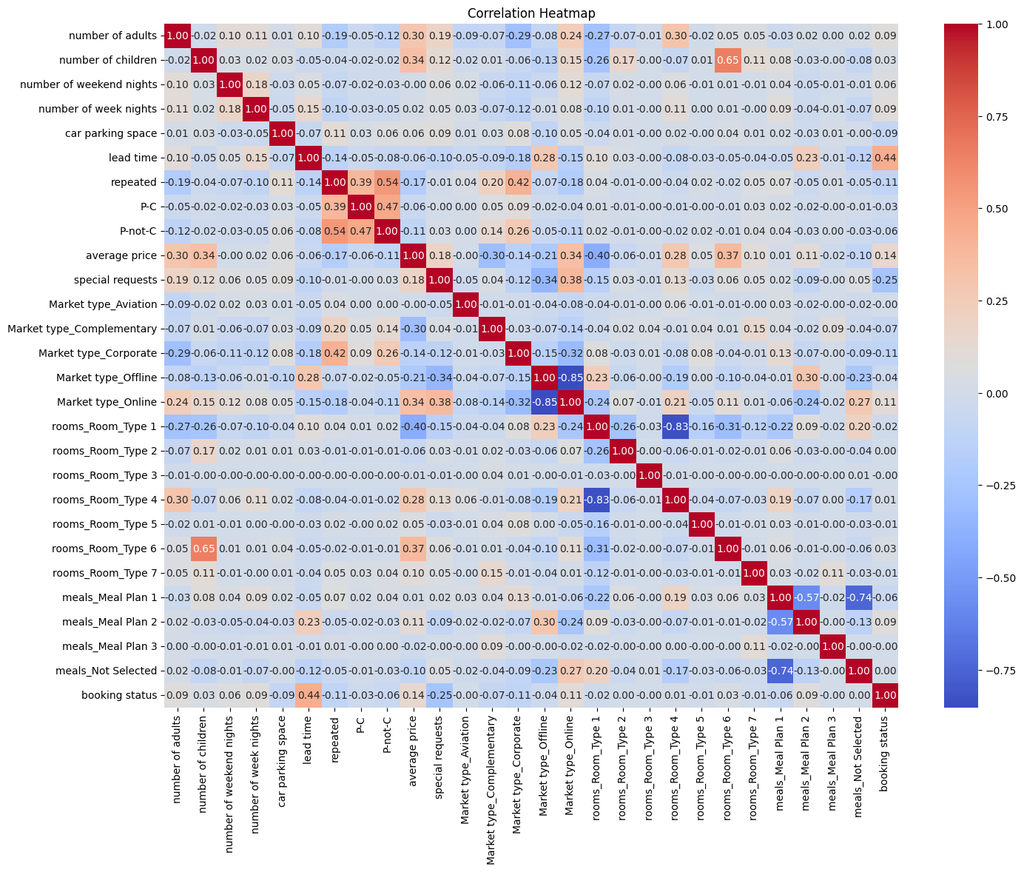

```python
# Using correlation heatmap for data visualisation to display encoded data before moving to machine learning algorithm models

df1 = pd.concat ([x,y],axis=1)

corr_matrix = df1.corr()

plt.figure(figsize=(16, 12))
sns.heatmap(corr_matrix, annot=True, cmap='coolwarm', fmt=".2f")
plt.title('Correlation Heatmap')
plt.show()
```

```python
# Based on target variable, Classification models will be the choice here due to binary values here
# Not only that, since I am predicting cancellation booking, I will need to find out which classification algorithm is accurate
# The higher the accuracy the better the model for this dataset, any other model would be unfit if they dont have high accuracy
# Starting with support vector machine model which is used for both regression and classification

from sklearn.svm import SVC

svc=SVC()
svc.fit(x_train,y_train)
y_pred=svc.predict(x_test)
y_pred
```

```
array([0, 0, 0, ..., 0, 0, 0], dtype=int64)
```

```python
# Now that model is built and fit into prediction, next is Model evaluation which will help in learning the accuracy of the model
# in order to get simple idea of both train and test data, we will start with bias and variance

bias=svc.score(x_train,y_train)
bias
```

```
0.7705014138906131
```

```python
variance= svc.score(x_test,y_test)
variance
```

```
0.7686896551724138
```

```python
# Although they have almost same score, its still best to compare with other evaluation metrics including cross validation

from sklearn.metrics import accuracy_score
acc=accuracy_score(y_test,y_pred)
acc
```

```
0.7686896551724138
```

```python
#import kfold for cross validation and cross val score for cross validation results
# Since the dataset is very large kfold would be more preferrable as more splits can be done for better accuracy
from sklearn.model_selection import cross_val_score, KFold

k=15

kfold = KFold(n_splits=k, shuffle=True, random_state=42)
```

```python
# Now to find the result of cross validation
cv_results = cross_val_score(svc, x, y, cv=kfold, scoring='accuracy')

print("Cross validation results: ", cv_results)
print("Mean accuracy: ", cv_results.mean())
print("Standard deviation of accuracy: ", cv_results.std())
```

```
Cross validation results:  [0.76375672 0.7600331  0.78237484 0.77285892 0.77368639 0.76251552
 0.77203144 0.75837815 0.77607616 0.77566225 0.76614238 0.76448675
 0.77524834 0.77028146 0.78228477]
Mean accuracy:  0.7703878136014123
Standard deviation of accuracy:  0.007298267283545734
```

```python
#importing confusion matrix for predicted and actual labels
from sklearn.metrics import confusion_matrix

cm= confusion_matrix(y_test,y_pred)
cm
```

```
array([[4584,  297],
       [1380,  989]], dtype=int64)
```

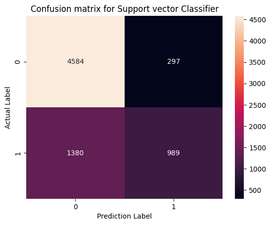

```python
# using heatmap for visualising confusion matrix of support vector classifier for true and false positives and negatives
sns.heatmap(cm, annot=True, fmt='d')
plt.title("Confusion matrix for Support vector Classifier")
plt.xlabel("Prediction Label")
plt.ylabel("Actual Label")
plt.show()
```

```python
#Classification report for support vector classifier model
from sklearn.metrics import classification_report
rt=classification_report(y_test,y_pred)
print("Classification report:\n", rt)
```

```
Classification report:
               precision    recall  f1-score   support

           0       0.77      0.94      0.85      4881
           1       0.77      0.42      0.54      2369

    accuracy                           0.77      7250
   macro avg       0.77      0.68      0.69      7250
weighted avg       0.77      0.77      0.75      7250
```

Now that The SVC model is done with some changes such as splits and comparing cross validation technique with other evaluation metrics and with that above i can conclude SVC model is 77% accurate with prediction for booking cancellation.

Conclusion: The model is decently accurate with 77% however lets continue with other classification algorithms for better comparison of results.

```python
# Next machine learning model is Random forest classification model
from sklearn.ensemble import RandomForestClassifier

rf= RandomForestClassifier()

rf.fit(x_train,y_train)
rf_preds=rf.predict(x_test)
rf_preds
```

```
array([0, 1, 0, ..., 0, 0, 0], dtype=int64)
```

```python
acc=accuracy_score(y_test,rf_preds)
acc
```

```
0.8852413793103449
```

```python
k=12

kfold = KFold(n_splits=k, shuffle=True, random_state=72)
```

```python
# Now to find the result of cross validation for random forest classifier
cv_results = cross_val_score(rf, x, y, cv=kfold, scoring='accuracy')

print("Cross validation results: ", cv_results)
print("Mean accuracy: ", cv_results.mean())
print("Standard deviation of accuracy: ", cv_results.std())
```

```
Cross validation results:  [0.88414432 0.89937107 0.88944058 0.89407481 0.88480636 0.89440583
 0.88282026 0.88149619 0.89304636 0.88245033 0.88675497 0.88807947]
Mean accuracy:  0.888407545269939
Standard deviation of accuracy:  0.005472180412431206
```

```python
cm= confusion_matrix(y_test,rf_preds)
cm
```

```
array([[4536,  345],
       [ 487, 1882]], dtype=int64)
```

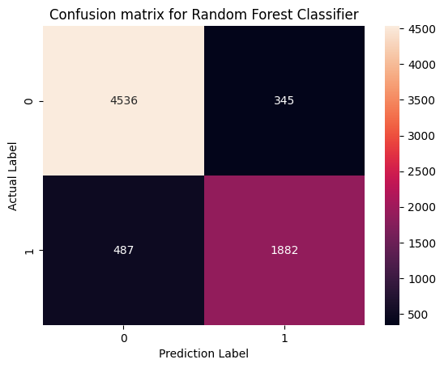

```python
# using heatmap for visualising confusion matrix of Random Forest classifier for true and false positives and negatives
sns.heatmap(cm, annot=True, fmt='d')
plt.title("Confusion matrix for Random Forest Classifier")
plt.xlabel("Prediction Label")
plt.ylabel("Actual Label")
plt.show()
```

```python
# Classification report for random forest model

rt=classification_report(y_test,rf_preds)
print("Classification report:\n", rt)
```

```
Classification report:
               precision    recall  f1-score   support

           0       0.90      0.93      0.92      4881
           1       0.85      0.79      0.82      2369

    accuracy                           0.89      7250
   macro avg       0.87      0.86      0.87      7250
weighted avg       0.88      0.89      0.88      7250
```

Based on Random forest model which is also used in regression is also useful in this case and the result has turned out be better than support vector model by significant difference like 0.12 or 12% difference and that is very significant.

Random forest model is reliable in this case due to high accuracy for predicting booking cancellation but before coming to complete conclusion, other models are to be still tested until optimal accuracy is produced.

```python
# Next model is Naive bayes algorithm including multinomial, gaussian and bernoulli

# importing multinomial naive bayes
from sklearn.naive_bayes import MultinomialNB


mnb = MultinomialNB()

mnb.fit(x_train, y_train)

mnb_pred=mnb.predict(x_test)
mnb_pred
```

```
array([0, 1, 0, ..., 0, 0, 0], dtype=int64)
```

```python
acc=accuracy_score(y_test,mnb_pred)
acc
```

```
0.7081379310344827
```

```python
k=15

kfold = KFold(n_splits=k, shuffle=True, random_state=52)
```

```python
# Now to find the result of cross validation for Multinomial Naive bayes
cv_results = cross_val_score(mnb, x, y, cv=kfold, scoring='accuracy')

print("Cross validation results: ", cv_results)
print("Mean accuracy: ", cv_results.mean())
print("Standard deviation of accuracy: ", cv_results.std())
```

```
Cross validation results:  [0.70666115 0.70211005 0.69383533 0.69011171 0.70211005 0.69797269
 0.70459247 0.70211005 0.70240066 0.71067881 0.68874172 0.70571192
 0.69412252 0.70033113 0.70198675]
Mean accuracy:  0.7002318017793389
Standard deviation of accuracy:  0.005975955877937632
```

```python
cm= confusion_matrix(y_test,mnb_pred)
cm
```

```
array([[3709, 1172],
       [ 944, 1425]], dtype=int64)
```

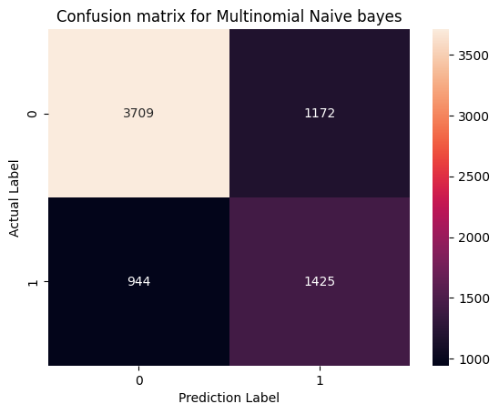

```python
# Heatmap for Multinomial Naive Bayes model
sns.heatmap(cm, annot=True, fmt='d')
plt.title("Confusion matrix for Multinomial Naive bayes")
plt.xlabel("Prediction Label")
plt.ylabel("Actual Label")
plt.show()
```

```python
# Classification report for multinomial naive bayes model
rt=classification_report(y_test,mnb_pred)
print("Classification report:\n", rt)
```

```
Classification report:
               precision    recall  f1-score   support

           0       0.80      0.76      0.78      4881
           1       0.55      0.60      0.57      2369

    accuracy                           0.71      7250
   macro avg       0.67      0.68      0.68      7250
weighted avg       0.72      0.71      0.71      7250
```

```python
# Importing Gaussian naive bayes
from sklearn.naive_bayes import GaussianNB

gnb= GaussianNB()

gnb.fit(x_train,y_train)

gnb_pred= gnb.predict(x_test)
```

```python
acc=accuracy_score(y_test,gnb_pred)
acc
```

```
0.4096551724137931
```

```python
k=15

kfold = KFold(n_splits=k, shuffle=True, random_state=42)
```

```python
cv_results = cross_val_score(gnb, x, y, cv=kfold, scoring='accuracy')

print("Cross validation results: ", cv_results)
print("Mean accuracy: ", cv_results.mean())
print("Standard deviation of accuracy: ", cv_results.std())
```

```
Cross validation results:  [0.40546132 0.41621845 0.40753    0.40049648 0.39346297 0.43152669
 0.40256516 0.42614812 0.40604305 0.39900662 0.41970199 0.41721854
 0.41846026 0.40687086 0.41266556]
Mean accuracy:  0.41089173815714836
Standard deviation of accuracy:  0.010223793194641279
```

```python
cm= confusion_matrix(y_test,gnb_pred)
cm
```

```
array([[ 695, 4186],
       [  94, 2275]], dtype=int64)
```

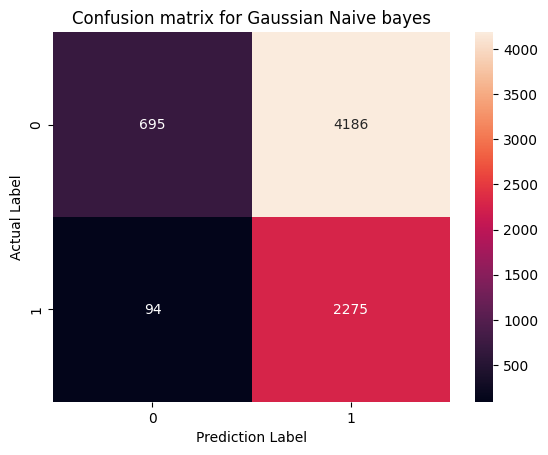

```python
# Heatmap for Gaussian Naive Bayes model
sns.heatmap(cm, annot=True, fmt='d')
plt.title("Confusion matrix for Gaussian Naive bayes")
plt.xlabel("Prediction Label")
plt.ylabel("Actual Label")
plt.show()
```

```python
# # Classification report for Gaussian naive bayes model

rt=classification_report(y_test,gnb_pred)
print("Classification report:\n", rt)
```

```
Classification report:
               precision    recall  f1-score   support

           0       0.88      0.14      0.25      4881
           1       0.35      0.96      0.52      2369

    accuracy                           0.41      7250
   macro avg       0.62      0.55      0.38      7250
weighted avg       0.71      0.41      0.33      7250
```

```python
# Importing Bernoulli Naive Bayes model

from sklearn.naive_bayes import BernoulliNB

bnb= BernoulliNB()

bnb.fit(x_train,y_train)
bnb_pred= bnb.predict(x_test)
```

```python
acc=accuracy_score(y_test,bnb_pred)
acc
```

```
0.7150344827586207
```

```python
k=15

kfold = KFold(n_splits=k, shuffle=True, random_state=42)
```

```python
cv_results = cross_val_score(bnb, x, y, cv=kfold, scoring='accuracy')

print("Cross validation results: ", cv_results)
print("Mean accuracy: ", cv_results.mean())
print("Standard deviation of accuracy: ", cv_results.std())
```

```
Cross validation results:  [0.70997104 0.71245345 0.72238312 0.73396773 0.71659082 0.70293753
 0.71741829 0.72114191 0.71978477 0.73427152 0.70778146 0.71854305
 0.71812914 0.71274834 0.72350993]
Mean accuracy:  0.7181088061843034
Standard deviation of accuracy:  0.008322348009922707
```

```python
cm= confusion_matrix(y_test,bnb_pred)
cm
```

```
array([[4161,  720],
       [1346, 1023]], dtype=int64)
```

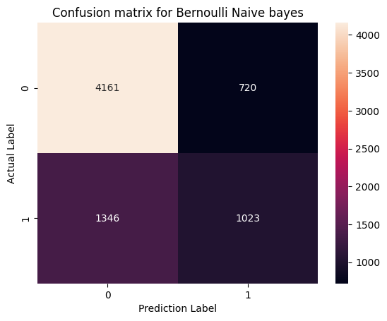

```python
# Heatmap for Bernoulli Naive Bayes model
sns.heatmap(cm, annot=True, fmt='d')
plt.title("Confusion matrix for Bernoulli Naive bayes")
plt.xlabel("Prediction Label")
plt.ylabel("Actual Label")
plt.show()
```

```python
# Classification report for Bernoulli naive bayes model
rt=classification_report(y_test,bnb_pred)
print("Classification report:\n", rt)
```

```
Classification report:
               precision    recall  f1-score   support

           0       0.76      0.85      0.80      4881
           1       0.59      0.43      0.50      2369

    accuracy                           0.72      7250
   macro avg       0.67      0.64      0.65      7250
weighted avg       0.70      0.72      0.70      7250
```

Based on Naive bayes classification algorithms Multinomial has accuracy of 71%, gaussian has accuracy of 41% and Bernoulli has accuracy of 72%. Only multinomial and bernoulli have about 70% but its still less compared to svc model which is nearly 80%.

Continuing with remaining classification models for checking optimal result.

```python
# Importing K neighbours classification model

from sklearn.neighbors import KNeighborsClassifier

# Hyperparameter tuning for KNN model

knn= KNeighborsClassifier(n_neighbors=5, metric='manhattan', algorithm='auto', weights='distance')

knn.fit(x_train,y_train)
knn_pred= knn.predict(x_test)
knn_pred
```

```
array([0, 1, 0, ..., 0, 0, 0], dtype=int64)
```

```python
acc=accuracy_score(y_test,knn_pred)
acc
```

```
0.84
```

```python
k=15

kfold = KFold(n_splits=k, shuffle=True, random_state=42)
```

```python
cv_results = cross_val_score(knn, x, y, cv=kfold, scoring='accuracy')

print("Cross validation results: ", cv_results)
print("Mean accuracy: ", cv_results.mean())
print("Standard deviation of accuracy: ", cv_results.std())
```

```
Cross validation results:  [0.84360778 0.85105503 0.83947042 0.84774514 0.85105503 0.84774514
 0.83616053 0.8415391  0.85637417 0.85513245 0.86051325 0.86092715
 0.8522351  0.8580298  0.85306291]
Mean accuracy:  0.850310199278291
Standard deviation of accuracy:  0.007310084029438862
```

```python
cm= confusion_matrix(y_test,knn_pred)
cm
```

```
array([[4367,  514],
       [ 646, 1723]], dtype=int64)
```

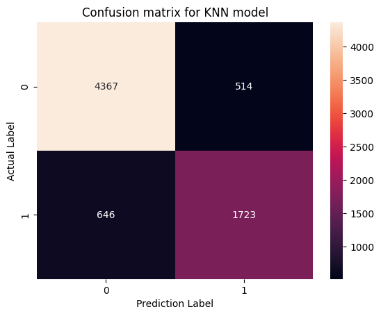

```python
# Heatmap for KNN Classification model
sns.heatmap(cm, annot=True, fmt='d')
plt.title("Confusion matrix for KNN model")
plt.xlabel("Prediction Label")
plt.ylabel("Actual Label")
plt.show()
```

```python
rt=classification_report(y_test,knn_pred)
print("Classification report:\n", rt)
```

```
Classification report:
               precision    recall  f1-score   support

           0       0.87      0.89      0.88      4881
           1       0.77      0.73      0.75      2369

    accuracy                           0.84      7250
   macro avg       0.82      0.81      0.82      7250
weighted avg       0.84      0.84      0.84      7250
```

KNN model just like some other models can be used for regression and classification models. Based on KNN classification results, it has 84% accuracy which is good but still slightly lower compared to random forest yet better than some of the models.

```python
# Importing Decision Tree classifier and gridsearch cross validation
from sklearn.model_selection import GridSearchCV
from sklearn.tree import DecisionTreeClassifier

dt= DecisionTreeClassifier()

# Hyperparameter tuning with the help of param dictionary value for decision tree model
param = {
    'criterion': ['gini', 'entropy'],
    'max_depth': [None, 5, 10, 15, 20],
    'min_samples_split': [2, 5, 10],
    'min_samples_leaf': [1, 2, 4],
    'max_features': ['auto', 'sqrt', 'log2', None]
}

grid_search = GridSearchCV(estimator=dt, param_grid=param, cv=15, scoring='accuracy')

grid_search.fit(x_train, y_train)
```

```
GridSearchCV(cv=15, estimator=DecisionTreeClassifier(),
             param_grid={'criterion': ['gini', 'entropy'],
                         'max_depth': [None, 5, 10, 15, 20],
                         'max_features': ['auto', 'sqrt', 'log2', None],
                         'min_samples_leaf': [1, 2, 4],
                         'min_samples_split': [2, 5, 10]},
             scoring='accuracy')
```

```python
best_params = grid_search.best_params_
print("Best Hyperparameters: ", best_params)
```

```
Best Hyperparameters:  {'criterion': 'entropy', 'max_depth': 15, 'max_features': None, 'min_samples_leaf': 2, 'min_samples_split': 2}
```

```python
best_dt = grid_search.best_estimator_
```

```python
dt_preds = best_dt.predict(x_test)
dt_preds
```

```
array([0, 1, 0, ..., 0, 0, 0], dtype=int64)
```

```python
acc=accuracy_score(y_test,dt_preds)
acc
```

```
0.8697931034482759
```

```python
cm= confusion_matrix(y_test,dt_preds)
cm
```

```
array([[4502,  379],
       [ 565, 1804]], dtype=int64)
```

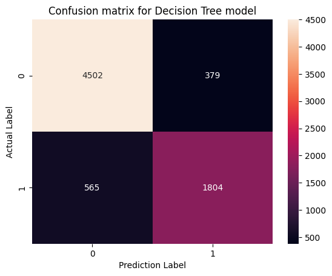

```python
# Heatmap for Decision tree classification model
sns.heatmap(cm, annot=True, fmt='d')
plt.title("Confusion matrix for Decision Tree model")
plt.xlabel("Prediction Label")
plt.ylabel("Actual Label")
plt.show()
```

```python
rt=classification_report(y_test,dt_preds)
print("Classification report:\n", rt)
```

```
Classification report:
               precision    recall  f1-score   support

           0       0.89      0.92      0.91      4881
           1       0.83      0.76      0.79      2369

    accuracy                           0.87      7250
   macro avg       0.86      0.84      0.85      7250
weighted avg       0.87      0.87      0.87      7250
```

Decision tree classification has 87% accuracy which is very similar result to random forest classifier, making it both about reliable for booking cancellation prediction. Continuing with remaining algorithm before conclusion of model results.

```python
# Importing feature scaling

from sklearn.preprocessing import StandardScaler
sc = StandardScaler()
x_train = sc.fit_transform(x_train)
x_test = sc.transform(x_test)
```

```python
# Importing Logistic Regression model

from sklearn.linear_model import LogisticRegression

# Hyperparameter tuning for logistic regression
lr= LogisticRegression(penalty='l1', C=1.0, solver='liblinear', max_iter=100, tol=1e-4, class_weight=None, random_state=42)

lr.fit(x_train,y_train)
lr_pred= lr.predict(x_test)
lr_pred
```

```
array([0, 1, 0, ..., 0, 0, 0], dtype=int64)
```

```python
acc=accuracy_score(y_test,lr_pred)
acc
```

```
0.8016551724137931
```

```python
k=15

kfold = KFold(n_splits=k, shuffle=True, random_state=42)
```

```python
cv_results = cross_val_score(lr, x, y, cv=kfold, scoring='accuracy')

print("Cross validation results: ", cv_results)
print("Mean accuracy: ", cv_results.mean())
print("Standard deviation of accuracy: ", cv_results.std())
```

```
Cross validation results:  [0.79437319 0.79478693 0.81547373 0.79892429 0.79437319 0.80057923
 0.80306165 0.8014067  0.80256623 0.80339404 0.79594371 0.80339404
 0.80215232 0.79759934 0.80629139]
Mean accuracy:  0.8009546639376529
Standard deviation of accuracy:  0.005323933752760071
```

```python
cm= confusion_matrix(y_test,lr_pred)
cm
```

```
array([[4384,  497],
       [ 941, 1428]], dtype=int64)
```

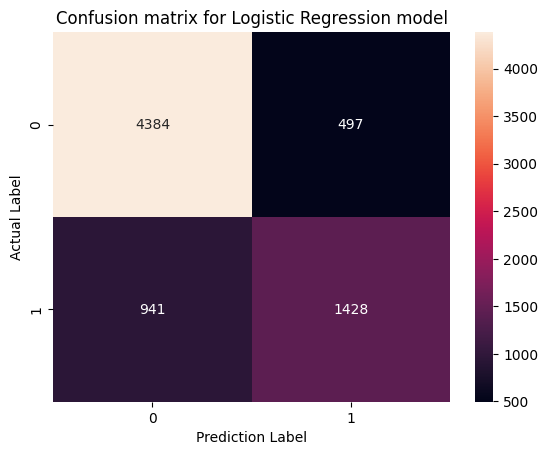

```python
# Heatmap for Logistic Regression model
sns.heatmap(cm, annot=True, fmt='d')
plt.title("Confusion matrix for Logistic Regression model")
plt.xlabel("Prediction Label")
plt.ylabel("Actual Label")
plt.show()
```

```python
# Classification report for logistic Regression model

rt=classification_report(y_test,lr_pred)
print("Classification report:\n", rt)
```

```
Classification report:
               precision    recall  f1-score   support

           0       0.82      0.90      0.86      4881
           1       0.74      0.60      0.67      2369

    accuracy                           0.80      7250
   macro avg       0.78      0.75      0.76      7250
weighted avg       0.80      0.80      0.80      7250
```

Based on overall machine learning models, The best model is Random forest model with 89% accuracy for prediction and more reliable than any other classification models.